# High Risk Counties Related to Opioid Prescribing

## by Chi Zhang

## Investigation Overview

> Investigate the risk level of counties through Opioid use and prescribing

## Dataset Overview

> There are 78 attributes and 12884 complete rows in the dataset. All variables are numeric execpt for year, FIPS, and two target variables that are binary. The main features of interest can be target_LAOPR_80,Long_Acting_Opioid_Pres2 and Opioid_Prescribing_Rate2 which all indicate the risk level of counties in terms of Opioid use and prescribing.

## Distributions of Beneficiaries in MA and FFS Programs

> The log transformed distribution of the two shows that MA is more spread out with a peak around 10, whereas FFS has a peak around 30. FFS being on the right of MA shows that there are more beneficiaries enrolled in FFS than MA.

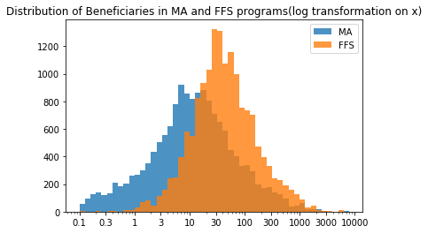

```python
bins_edge = 10**np.arange(-1, np.log10(df["MA_Beneficiaries"].max())+0.1, 0.1)
plt.hist(df["MA_Beneficiaries"], bins = bins_edge, alpha = 0.8, label = 'MA')
plt.xscale('log')
tick_locs = [0.1, 0.3, 1, 3, 10,30,100,300,1000,3000,10000]
plt.xticks(tick_locs, tick_locs)
plt.title('Distribution of MA Beneficiaries(log trans)');
bins_edge = 10**np.arange(-1, np.log10(df["FFS_Beneficiaries"].max())+0.1, 0.1)
plt.hist(df["FFS_Beneficiaries"], bins = bins_edge, alpha = 0.8, label = 'FFS')
plt.xscale('log')
tick_locs = [0.1,0.3, 1,3, 10,30,100,300,1000,3000,10000]
plt.xticks(tick_locs, tick_locs)
plt.legend()
plt.title('Distribution of Beneficiaries in MA and FFS programs(log transformation on x)');
```

## Compare Long acting and overall Opioid Rates against Poverty Rates

> Compared the two graphs, long acting opioid rates decrease as poverty rate increases, but the overall opioid rates do not.

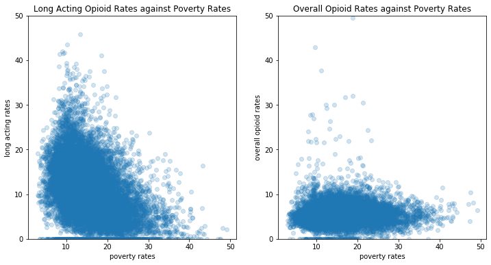

```python
df['SDOH_All_ages_in_Poverty_Rate'] = df['All_ages_in_Poverty_Count_Est']/df['POP_ESTIMATE_2']*100
fig, ax = plt.subplots(ncols = 2, nrows = 1 , figsize = [12,6])
ax[0].scatter(data = df, x = 'SDOH_All_ages_in_Poverty_Rate', y = 'Long_Acting_Opioid_Pres2', alpha = 0.2)
ax[0].set_ylim([0, 50])
ax[0].set_xlabel('poverty rates')
ax[0].set_ylabel('long acting rates')
ax[0].set_title('Long Acting Opioid Rates against Poverty Rates')
ax[1].scatter(data = df, x = 'SDOH_All_ages_in_Poverty_Rate', y = 'Opioid_Prescribing_Rate2', alpha = 0.2)
ax[1].set_ylim([0, 50])
ax[1].set_xlabel('poverty rates')
ax[1].set_ylabel('overall opioid rates')
ax[1].set_title('Overall Opioid Rates against Poverty Rates')
plt.show()
```

## Net Migration vs. Long Acting Opioid Prescribing Rates

> The graph between positive net migration and long acting rate shows that counties with large number of migrations tend to have long acting rates concentrated around 15.

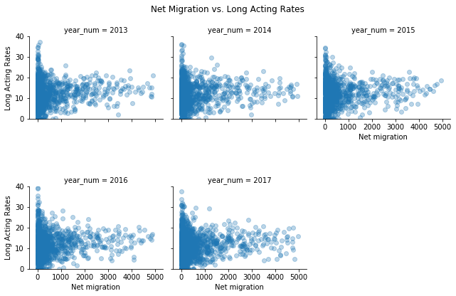

```python
df_mig = df[(df['NET_MIG_'] > 0) & (df['NET_MIG_'] < 5000)]
g = sb.FacetGrid(data = df_mig, col='year_num',col_wrap = 3,ylim = [0, 40])
plt.subplots_adjust(top=0.3)
g.fig.suptitle('Net Migration vs. Long Acting Rates')
g.map(plt.scatter,'NET_MIG_','Long_Acting_Opioid_Pres2',alpha = 0.3)
g.set_ylabels('Long Acting Rates')
g.set_xlabels('Net migration')
plt.show()
```

## Risk Accessment between MA and FFS Beneficiaries

> Though There is no clear correlation between Long Acting Rates and number of beneficiaries; over the years, FFS benes in high risk counties have been increasing to catch up to low risk counties. MA benes on the other hand, shows a gap between high risk and low risk counties, especially in 2016 and 2017.

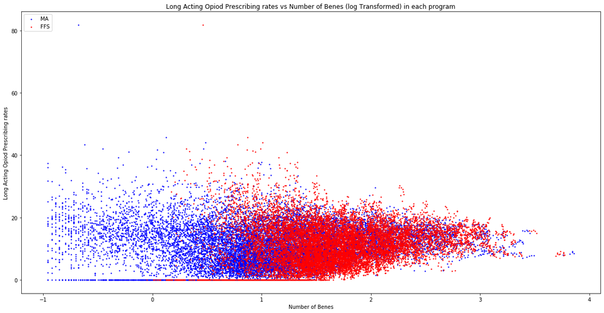

```python
df['log_MA'] = df['MA_Beneficiaries'].apply(np.log10)
df['log_FFS'] = df['FFS_Beneficiaries'].apply(np.log10)
fig, ax1 = plt.subplots(figsize = [20,10])
ax1.scatter(df['log_MA'], df['Long_Acting_Opioid_Pres2'], s=2, c='b', label='MA')
ax1.scatter(df['log_FFS'], df['Long_Acting_Opioid_Pres2'], s=2, c='r', label='FFS')
plt.legend(loc='upper left')
plt.title('Long Acting Opiod Prescribing rates vs Number of Benes (log Transformed) in each program')
plt.ylabel('Long Acting Opiod Prescribing rates')
plt.xlabel('Number of Benes');
```

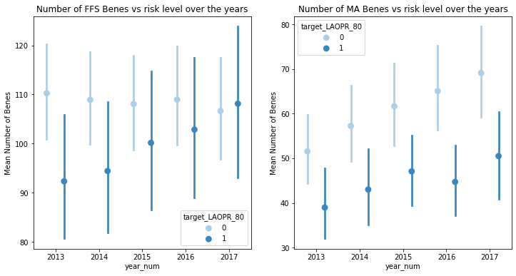

```python
fig, ax = plt.subplots(ncols = 2, figsize = [12,6])
sb.pointplot(data = df, x = 'year_num', y = 'FFS_Beneficiaries', hue = 'target_LAOPR_80',
           palette = 'Blues', linestyles = '', dodge = 0.4, ax = ax[0])
ax[0].set_title('Number of FFS Benes vs risk level over the years')
ax[0].set_ylabel('Mean Number of Benes')
sb.pointplot(data = df, x = 'year_num', y = 'MA_Beneficiaries', hue = 'target_LAOPR_80',
           palette = 'Blues', linestyles = '', dodge = 0.4, ax = ax[1])
ax[1].set_title('Number of MA Benes vs risk level over the years')
ax[1].set_ylabel('Mean Number of Benes')
plt.show();
```